# FruitClassificator

```python
import numpy as np
import pandas as pd
import matplotlib.pyplot as plt
import tensorflow as tf
from tensorflow.keras import layers, datasets, models
from tensorflow import keras
from keras.preprocessing.image import img_to_array
```

In this notebook, I developed an algorithm to classify photos containing individual fruits or vegetables (image-level labels).

As a first step, I divided the train set into two parts (train and vaidation) with an 80/20 ratio

```python
#The train_dir is based on my directory, if you want to run the model you have to change it.
train_dir = f"C:/Users/pc_hu/Desktop/Happie Project/fruits-360_dataset/fruits-360/Training"
batch_size = 16
train_ds = tf.keras.preprocessing.image_dataset_from_directory(
              train_dir,
              validation_split=0.2,
              labels='inferred',
              subset='training',
              seed=42,
              batch_size=batch_size,
              image_size=(100, 100))
```

```
Found 67692 files belonging to 131 classes.
Using 54154 files for training.
```

```python
val_ds = tf.keras.preprocessing.image_dataset_from_directory(
              train_dir,
              validation_split=0.2,
              labels='inferred',
              subset='validation',
              seed=42,
              batch_size=batch_size,
              image_size=(100, 100))
```

```
Found 67692 files belonging to 131 classes.
Using 13538 files for validation.
```

```python
#The test_dir is based on my directory, if you want to run the model you have to change it.
test_dir = f"C:/Users/pc_hu/Desktop/Happie Project/fruits-360_dataset/fruits-360/Test"
test_ds = tf.keras.preprocessing.image_dataset_from_directory(
              test_dir,
              labels='inferred',
              seed=42,
              batch_size=batch_size,
              image_size=(100, 100))
```

```
Found 22688 files belonging to 131 classes.
```

```python
class_names = train_ds.class_names
```

Prefetching overlaps the preprocessing and model execution of a training step. While the model is executing training step s, the input pipeline is reading the data for step s+1. Doing so reduces the step time to the maximum (as opposed to the sum) of the training and the time it takes to extract the data.

```python
AUTOTUNE = tf.data.experimental.AUTOTUNE

train_ds = train_ds.cache().shuffle(1000).prefetch(buffer_size=AUTOTUNE)
val_ds = val_ds.cache().prefetch(buffer_size=AUTOTUNE)
```

As a classification algorithm, I decided to use a pre-trained resnet50 on imagenet.

The choice of model was mainly based on two factors:

1) Simplicity of implementation but at the same time ability to recognize images;

2) To develop the "bonus" project, doing some research on the Internet, I found a paper [1] where they used in the first steps the resnet50 model.

[1] https://www.mdpi.com/2313-433X/8/8/215

```python
data_augmentation = tf.keras.Sequential([
    tf.keras.layers.experimental.preprocessing.RandomFlip('horizontal'),
    tf.keras.layers.experimental.preprocessing.RandomRotation(0.2)
])

preprocess_input = tf.keras.applications.resnet.preprocess_input

#The input shape is adapted on the images used to train the model
base_model = tf.keras.applications.resnet.ResNet50(
    input_shape=(100, 100, 3),
    include_top=False,
    weights='imagenet')

#To speed up the training, I froze the weights of the resnet50 network
base_model.trainable = False

global_average_layer = tf.keras.layers.GlobalAveragePooling2D()

#In the output dense layer I entered the number of labels
prediction_layer = tf.keras.layers.Dense(131)
```

```python
inputs = tf.keras.Input(shape=(100, 100, 3))
x = data_augmentation(inputs)
x = preprocess_input(x)
x = base_model(x, training=False)
x = global_average_layer(x)
x = tf.keras.layers.Dropout(0.2)(x)
outputs = prediction_layer(x)

model = tf.keras.Model(inputs=inputs, outputs=outputs)
```

```python
optimizer = tf.keras.optimizers.Adam(learning_rate=0.0001)

model.compile(
    optimizer=optimizer,
    loss=tf.keras.losses.SparseCategoricalCrossentropy(from_logits=True),
    metrics=['accuracy']
)
```

```python
model.summary()
```

```
Model: "functional_1"
_________________________________________________________________
Layer (type)                 Output Shape              Param #
=================================================================
input_2 (InputLayer)         [(None, 100, 100, 3)]     0
_________________________________________________________________
sequential (Sequential)      (None, 100, 100, 3)       0
_________________________________________________________________
tf_op_layer_strided_slice (T [(None, 100, 100, 3)]     0
_________________________________________________________________
tf_op_layer_BiasAdd (TensorF [(None, 100, 100, 3)]     0
_________________________________________________________________
resnet50 (Functional)        (None, 4, 4, 2048)        23587712
_________________________________________________________________
global_average_pooling2d (Gl (None, 2048)              0
_________________________________________________________________
dropout (Dropout)            (None, 2048)              0
_________________________________________________________________
dense (Dense)                (None, 131)               268419
=================================================================
Total params: 23,856,131
Trainable params: 268,419
Non-trainable params: 23,587,712
_________________________________________________________________
```

```python
epochs = 15
history = model.fit(
    train_ds,
    epochs=epochs,
    validation_data=val_ds
)
```

[output not shown]

We can also observe this in the two graphs below.

In the first graph we can see the train and validation loss

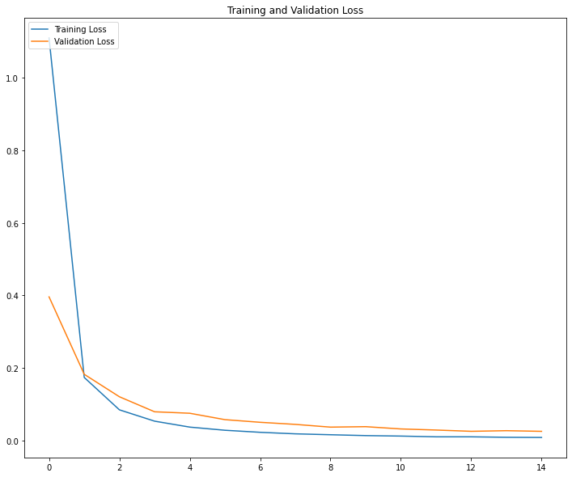

```python
train_loss = history.history['loss']
val_loss = history.history['val_loss']

epochs_range = range(epochs)

plt.figure(figsize=(12, 10))
plt.plot(epochs_range, train_loss, label="Training Loss")
plt.plot(epochs_range, val_loss, label="Validation Loss")
plt.legend(loc='upper left')
plt.title('Training and Validation Loss')

plt.show()
```

In the second graph we can see the train and validation accuracy

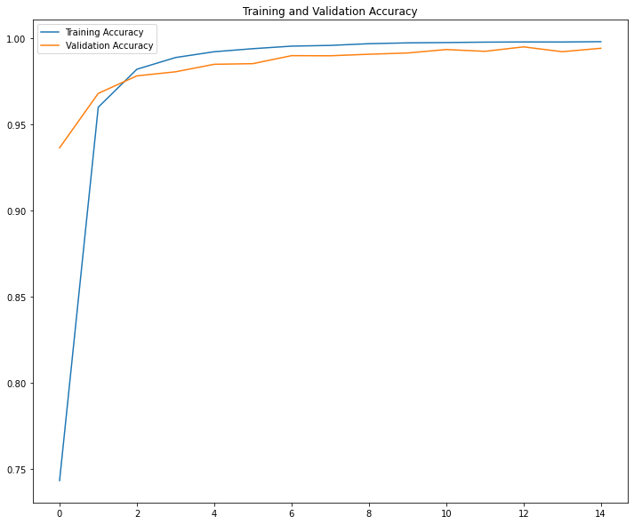

```python
train_acc = history.history['accuracy']
val_acc = history.history['val_accuracy']

epochs_range = range(epochs)

plt.figure(figsize=(12, 10))
plt.plot(epochs_range, train_acc, label="Training Accuracy")
plt.plot(epochs_range, val_acc, label="Validation Accuracy")
plt.legend(loc='upper left')
plt.title('Training and Validation Accuracy')

plt.show()
```

```python
def predict(model, img):
    img_array = img_to_array(images[i].numpy())
    img_array = tf.expand_dims(img_array, 0)

    predictions = model.predict(img_array)

    predicted_class = class_names[np.argmax(predictions[0])]
    confidence = round(100*(np.max(predictions[0])), 0)
    class_int = np.argmax(predictions[0])
    return predicted_class, confidence, class_int/131
```

As a final step, I printed model predictions on the test set

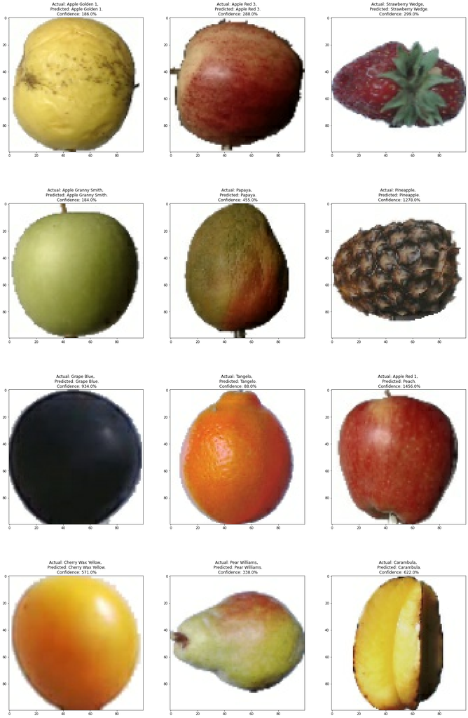

```python
plt.figure(figsize=(25, 40))
for images, labels in test_ds.take(1):
    for i in range(12):
        ax = plt.subplot(4, 3, i+1)
        plt.imshow(images[i].numpy().astype("uint8"))

        predicted_class, confidence, class_int = predict(model, images[i].numpy())
        if confidence < 0:
            confidence = confidence*-1
        actual_class = class_names[labels[i]]

        plt.title(f"Actual: {actual_class}, \n Predicted: {predicted_class}.\n Confidence: {confidence}%")
```

As we might expect from the validation accuracy value (99.41%), the model is able to recognize very well the images we pass to it as input